# Homework5

Fifi

November 7, 2016

### Body Temperature Study

I am interested in knowing whether my body temperature changes significantly after eating and after a full day of acitivities, therefore I measured and collected my body temperature at 3 time points of the day: in the morning (immediately after waking), after breakfast, and at the night (right before go to bed). The data will be compared using t test to see if there’s a significant difference.

### Data collection

I took temperature using an electronic thermometer under armpit. There are several days that I forgot to take temperature at night, and the corresponding temperature entries were left as blank.

### Examine basic statistics of three temperatures: mean, median, range, standard deviation

|  | Morning | After Breakfast | Night |
| --- | --- | --- | --- |
| mean | 35.8130435 | 35.7956522 | 35.8000000 |
| median | 35.8000000 | 35.8000000 | 35.8000000 |
| range | 1.1000000 | 0.9000000 | 1.5000000 |
| standard deviation | 0.2958875 | 0.2653955 | 0.3244428 |

The means for all three groups are very close. No trend of change can be observed. The range of temperature at night is slightly greater than at morning and after breakfast, possibly due to different amount of activities being done during the day. The standard distribution indicates the temperature distribution is not spread out in each group. One thing worth mentioning is that the median for all groups is the same–35.8 degrees. I think this is my baseline temperature.

### Paired t test between morning temperature and after breakfast termperature

Does body temperature change significantly after eating? A paired t test was done to calculate the significance of difference between 2 sets of temperature.

```
##
##  Paired t-test
##
## data:  temperaturedata$Morning and temperaturedata$Breakfast
## t = 0.33883, df = 22, p-value = 0.7379
## alternative hypothesis: true difference in means is not equal to 0
## 95 percent confidence interval:
##  -0.08905463  0.12383724
## sample estimates:
## mean of the differences
##               0.0173913
```

p value>0.05, so there is no significant change of temperature after eating.

### Generate scatter plot to see the linear relationship between morning temperature and after breakfast temperature

```
##
## Call:
## lm(formula = formula(Morning ~ Breakfast), data = temperaturedata)
##
## Residuals:
##      Min       1Q   Median       3Q      Max
## -0.47778 -0.15802 -0.01605  0.18765  0.41481
##
## Coefficients:
##             Estimate Std. Error t value Pr(>|t|)
## (Intercept)  11.0654     6.8323   1.620   0.1202
## Breakfast     0.6914     0.1909   3.622   0.0016 **
## ---
## Signif. codes:  0 '***' 0.001 '**' 0.01 '*' 0.05 '.' 0.1 ' ' 1
##
## Residual standard error: 0.2376 on 21 degrees of freedom
## Multiple R-squared:  0.3845, Adjusted R-squared:  0.3552
## F-statistic: 13.12 on 1 and 21 DF,  p-value: 0.001597
```

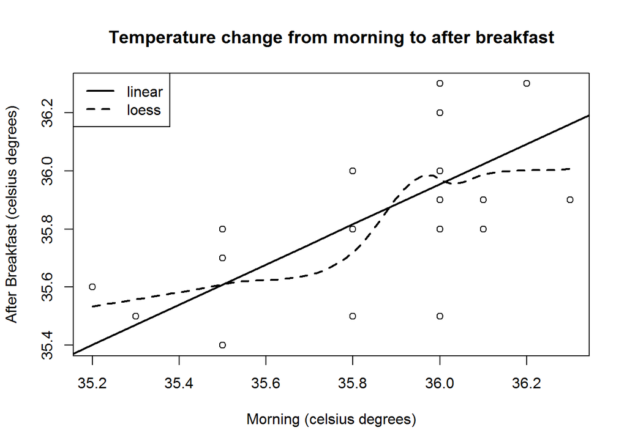

The linear model and the plot suggest that there’s a positive linear correlation between the morning temperature and the after breakfast temperature. It means that if I have high temperature when I wake, I tend to have high temperature after breakfast, but not necessary higher than the morning temperature.

### Paired t test between morning temperature and night termperature

Does body temperature change significantly after a full day of activity?

```
##
##  Paired t-test
##
## data:  temperaturedata$Morning and temperaturedata$Night
## t = -0.36972, df = 19, p-value = 0.7157
## alternative hypothesis: true difference in means is not equal to 0
## 95 percent confidence interval:
##  -0.1665288  0.1165288
## sample estimates:
## mean of the differences
##                  -0.025
```

p value>0.05, so there is no significant change of temperature after a full day of activity.

### Generate scatter plot to see the linear relationship between morning temperature and night temperature

```
##
## Call:
## lm(formula = formula(Morning ~ Night), data = temperaturedata)
##
## Residuals:
##    Min     1Q Median     3Q    Max
## -0.437 -0.166 -0.009  0.179  0.425
##
## Coefficients:
##             Estimate Std. Error t value Pr(>|t|)
## (Intercept)  19.3070     6.4107   3.012  0.00749 **
## Night         0.4600     0.1791   2.569  0.01932 *
## ---
## Signif. codes:  0 '***' 0.001 '**' 0.01 '*' 0.05 '.' 0.1 ' ' 1
##
## Residual standard error: 0.2532 on 18 degrees of freedom
##   (3 observations deleted due to missingness)
## Multiple R-squared:  0.2683, Adjusted R-squared:  0.2276
## F-statistic: 6.599 on 1 and 18 DF,  p-value: 0.01932
```

[figure not shown]

The R-squared suggests that the trend is weaker than that between the morning and breakfast, but a positive correlation still exists between the morning and night temperature. The weaker trend is probably a result of longer time interval and a larger amount of activities between 2 temperature taking points.